# Pennsylvania COVID-19 Investigation

RK

2022-02-26

## Data Import and Cleansing

The first thing we did in this investigation was source our data set from John Hopkins’ github repository. We did this by using the static part of the URL as a template and concatenated the file name into a list of file location variables. We then read each of the variables into tables using the read_csv function.

When our tables are loaded we then pivot the data sets so that we can investigate by State, Date, and Cases. In the case of the number of US deaths we look at State, Date, and Death.

```r
library(tidyverse)
library(lubridate)
url <- "https://raw.githubusercontent.com/CSSEGISandData/COVID-19/master/csse_covid_19_data/csse_covid_19_time_series/"
files <- c("time_series_covid19_confirmed_US.csv",
           "time_series_covid19_deaths_US.csv")
data_locs <- str_c(url,files)
us_conf <- read_csv(data_locs[1])
us_deaths <- read_csv(data_locs[2])
us_conf <- us_conf %>%
  pivot_longer(cols = -c(Country_Region,UID,Lat,Long_,iso2,iso3,
                         code3,FIPS,Admin2,Province_State,Combined_Key),
                names_to = "Date",
                values_to = "Cases") %>%
  select(Province_State, Combined_Key,Date,Cases)

us_deaths <- us_deaths %>%
  pivot_longer(cols = -c(Country_Region,UID,Lat,Long_,iso2,iso3,
                         code3,FIPS,Admin2,Province_State,Combined_Key,Population),
                names_to = "Date",
                values_to = "Deaths") %>%
  select(Province_State, Combined_Key,Date,Deaths)

us_covid <- us_conf %>%
  full_join(us_deaths) %>%
  mutate(Date = mdy(Date))
```

## COVID-19 Data Analysis

In order to support our analysis of Pennsylvania specific COVID-19 metric we take a subset of the US Covid data we pivoted out during our data importation based on Province_State and sum Case/Death by Date in a table which we use to based our analysis on.

The first analysis we do looks at total cases vs total deaths from early 2020 until Feb of 2022. As can be seen below total deaths are a very small number compared to cases. Particularly interesting is the how fast the total cases rise during the period when delta and omicron variants are active, while deaths seem to be linear in comparison.

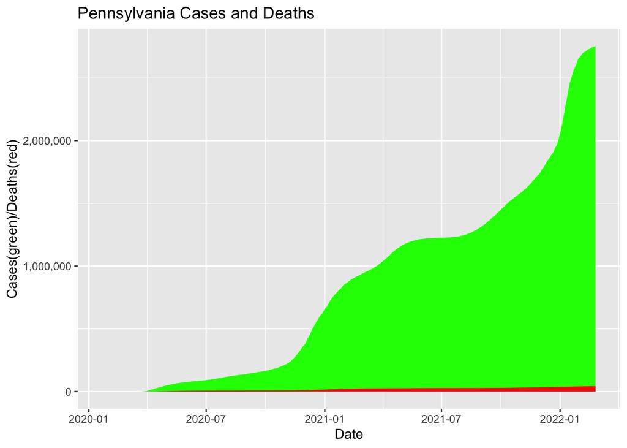

```r
covid_pa_case_death_comp = us_covid %>% filter(Province_State == 'Pennsylvania') %>%
  select(Date,Cases,Deaths) %>% group_by(Date) %>%
  summarise(Cases = sum(Cases),Deaths =sum(Deaths))

ggplot(data=covid_pa_case_death_comp, aes(Date,Cases)) +
    geom_area(aes(Date,Cases),fill="green") +
    geom_area(aes(Date,Deaths),fill="red") +
    xlab("Date") + ylab("Cases(green)/Deaths(red)") +
    ggtitle("Pennsylvania Cases and Deaths") +
    scale_y_continuous(labels = scales::comma)
```

While this might seem like good news, it fails to represent the total deaths and the severity of the overall situation. Look more closely at total deaths we see that death rates rise along with with case count. What this seems to indicate is that while the newer variants spread more easily and are overall less deadly, there is still a significant portion of the population that is susceptible to complications from COVID-19.

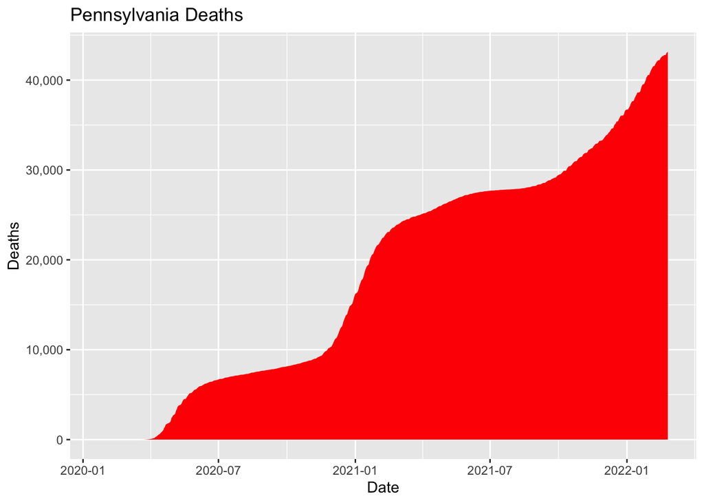

```r
covid_pa_deaths = us_covid %>% filter(Province_State == 'Pennsylvania') %>%
  select(Date,Deaths) %>% group_by(Date) %>%
  summarise(Deaths =sum(Deaths))

ggplot(data=covid_pa_case_death_comp, aes(Date,Deaths)) +
    geom_area(aes(Date,Deaths),fill="red") +
    xlab("Date") + ylab("Deaths") +
    ggtitle("Pennsylvania Deaths") +
    scale_y_continuous(labels = scales::comma)
```

## COVID-19 Rate of Change Modeling

```r
covid_pa_cases = us_covid %>% filter(Province_State == 'Pennsylvania') %>%
  select(Date,Cases)
covid_pa_case_trend <- covid_pa_cases %>% mutate(Difference=Cases-lag(Cases))

mod <- lm(Difference ~ poly(as.numeric(Date), 15), data=covid_pa_case_trend)
summary(mod)
```

```
##
## Call:
## lm(formula = Difference ~ poly(as.numeric(Date), 15), data = covid_pa_case_trend)
##
## Residuals:
##     Min      1Q  Median      3Q     Max
## -293366    -169      -4     145   10919
##
## Coefficients:
##                                Estimate Std. Error t value Pr(>|t|)
## (Intercept)                       2.017      9.893   0.204    0.838
## poly(as.numeric(Date), 15)1   27902.170   2274.379  12.268   <2e-16 ***
## poly(as.numeric(Date), 15)2  -23305.230   2274.422 -10.247   <2e-16 ***
## poly(as.numeric(Date), 15)3   34204.624   2274.463  15.039   <2e-16 ***
## poly(as.numeric(Date), 15)4  -31930.268   2274.504 -14.038   <2e-16 ***
## poly(as.numeric(Date), 15)5   33293.257   2274.543  14.637   <2e-16 ***
## poly(as.numeric(Date), 15)6  -46893.913   2274.580 -20.617   <2e-16 ***
## poly(as.numeric(Date), 15)7   40704.220   2274.616  17.895   <2e-16 ***
## poly(as.numeric(Date), 15)8  -46792.136   2274.649 -20.571   <2e-16 ***
## poly(as.numeric(Date), 15)9   43316.165   2274.679  19.043   <2e-16 ***
## poly(as.numeric(Date), 15)10 -50752.446   2274.707 -22.312   <2e-16 ***
## poly(as.numeric(Date), 15)11  51907.877   2274.733  22.819   <2e-16 ***
## poly(as.numeric(Date), 15)12 -50441.737   2274.755 -22.175   <2e-16 ***
## poly(as.numeric(Date), 15)13  55235.556   2274.774  24.282   <2e-16 ***
## poly(as.numeric(Date), 15)14 -50252.695   2274.791 -22.091   <2e-16 ***
## poly(as.numeric(Date), 15)15  57969.954   2274.804  25.483   <2e-16 ***
## ---
## Signif. codes:  0 '***' 0.001 '**' 0.01 '*' 0.05 '.' 0.1 ' ' 1
##
## Residual standard error: 2274 on 52837 degrees of freedom
##   (1 observation deleted due to missingness)
## Multiple R-squared:  0.09645,    Adjusted R-squared:  0.09619
## F-statistic:   376 on 15 and 52837 DF,  p-value: < 2.2e-16
```

```r
pred <- data.frame(Date=seq(as.Date("2020-03-01"), as.Date("2022-02-22"), by = "day"))
pred$value <- predict(mod,newdata=pred)
summary(pred)
```

```
##       Date                value
##  Min.   :2020-03-01   Min.   :-717.49
##  1st Qu.:2020-08-28   1st Qu.:-102.90
##  Median :2021-02-25   Median :  48.61
##  Mean   :2021-02-25   Mean   :  40.18
##  3rd Qu.:2021-08-25   3rd Qu.: 192.90
##  Max.   :2022-02-22   Max.   : 501.71
```

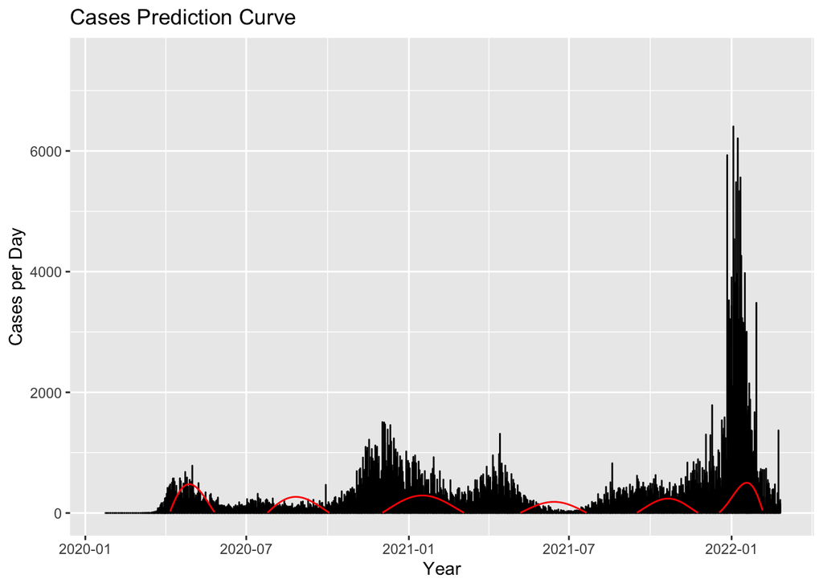

```r
ggplot(data=covid_pa_case_trend,aes(x=Date, y=Difference)) +
  geom_line(aes(x=Date, y=Difference)) +
  geom_line(data=pred,aes(x=Date, y=value), color="red") +
  xlab("Year") + ylab("Cases per Day") +
  ggtitle("Cases Prediction Curve") +
  ylim(0, 7500)
```

## Conclusion and Possible Bias

The analysis of COVID-19 Data in relation to Pennsylvania Cases and Death show that while the pandemic may be moving toward becoming an endemic situation, we should still take measure to mitigate harm to those at risk of complication. The analysis clear shows that while the comparative rates between deaths and cases is getting smaller as time passes, there is still a significant number of people dying due to COVID-19 related complications.

My own personal bias here was a perception that COVID-19 was not as severe as it was in the early stages and that deaths were declining. In order to mitigate this I specifically made sure that all death numbers were included and after my analysis was complete, compared my findings to the results of similar studies to assure that my methodology was sound and results were within sane ranges.